# Classification in High-Dimensions

Kim Siegmund

7/8/2020

## Background

```r
if (!require(MASS)) install.packages("MASS") # package needed to generate correlated precictors
if (!require(glmnet)) install.packages("glmnet") # package needed to perform ridge/lasso/elastic net regression
library(MASS)
library(glmnet)

# function to turn log odds into probability
expit <- function(x){
  ex <- exp(x)
  p  <- ex/(1+ex)
  p
}
```

Let’s simulate an outcome variable with 2 classes, and use the logisitic (binomial) model to predict class. This time I’m going to simulate predictors that are correlated.

Turn example 3 into a classification exercise, in high dimensions: https://www4.stat.ncsu.edu/~post/josh/LASSO_Ridge_Elastic_Net_-_Examples.html#example-3

Example 3 uses a correlation matrix that is strongest between neighbors, and the correlation decays with # neighbors apart.

**Ex 3. Correlation matrix**

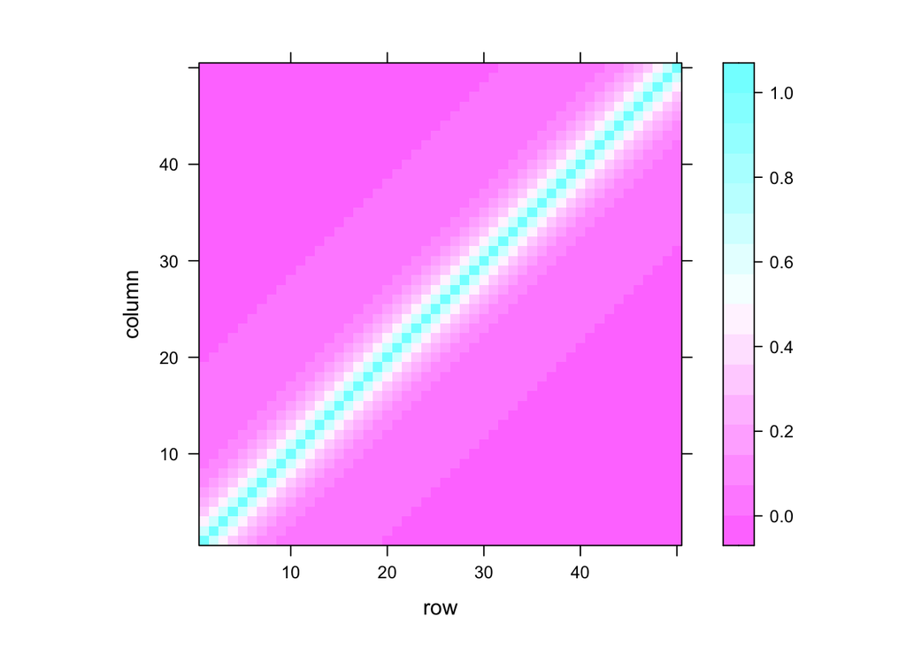

```r
p<-50
CovMatrix <- outer(1:p, 1:p, function(x,y) {.7^abs(x-y)})
lattice::levelplot(as.matrix(CovMatrix))
```

**Blk diag Corr matrix**

I’m going to use a block diagonal matrix instead. I’ll show the correlation structure for the first 100 variables, but we’ll model 1000.

```r
blocksize <- 5
CovMatrix <- outer(rep(0.9,blocksize), rep(0.9,blocksize)) + (1-0.9^2)*diag(blocksize)
CovMatrix
```

```
##      [,1] [,2] [,3] [,4] [,5]
## [1,] 1.00 0.81 0.81 0.81 0.81
## [2,] 0.81 1.00 0.81 0.81 0.81
## [3,] 0.81 0.81 1.00 0.81 0.81
## [4,] 0.81 0.81 0.81 1.00 0.81
## [5,] 0.81 0.81 0.81 0.81 1.00
```

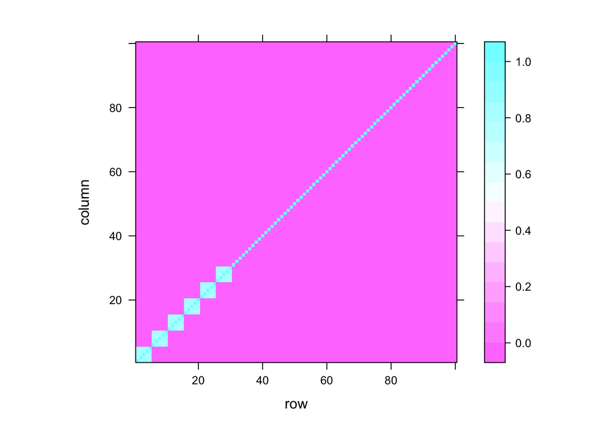

```r
IdpMatrix <- diag(70)
BlockMtrx <- Matrix::bdiag(CovMatrix,CovMatrix,CovMatrix,CovMatrix,CovMatrix,CovMatrix,IdpMatrix)

lattice::levelplot(as.matrix(BlockMtrx))
```

## Correlated X

**Model information**

n=500 p=1000

The first 15 model parameters are informative of class. Model Parameters = 2-4’s, 3-2’s, 10-1’s, 985- 0’s  
We’ll specify an exchangeable correlation structure: 6 blocks of 5 features with cor=0.81 and 970 uncorrelated features.

**Generate data**

First, create the block diagonal covariance matrix for the predictors X.

```r
set.seed(22)
n <- 500    # Number of observations
p <- 1000     # Number of predictors included in model
blocksize <- 5
CovMatrix <- outer(rep(0.9,blocksize), rep(0.9,blocksize)) + (1-0.9^2)*diag(blocksize)
BlkMtrx <- Matrix::bdiag(CovMatrix,CovMatrix,CovMatrix,CovMatrix,CovMatrix,CovMatrix)
```

Now simulate X, with the first 30 variables coming from a block diagonal matrix and the last 970 as iid random normal deviates.

```r
# make X matrix
x30 <- mvrnorm(n=n, rep(0,30), BlkMtrx) # n observations from the correlated X variables
xp <- replicate(n=(p-30),rnorm(n,0,1)) # n observatins from the independent X variables
x <- cbind(x30,xp)  #  X matrix
```

Estimate outcome from the logistic regression model. This will be the logit p, with p the binomial probability of y=1.

```r
logitp <-  4 * apply(x[, 1:2], 1, sum) +
  2 * apply(x[, 3:5], 1, sum) +
  apply(x[, 6:15], 1, sum)  # the first 15 variables are informative of class
```

Randomly sample outcome (y) from a binomial distribution with probability p. This is a vector of length 500.

```r
prb <- expit(logitp)     # probabilty y=1
y <- rbinom(length(prb),1,prb)  # y is class 1 with probability prb and class 0 otherwise
table(prb>0.5,y)        # table of probability vs class (1/0)
```

```
##        y
##           0   1
##   FALSE 240   5
##   TRUE   11 244
```

Split data into train and test sets

```r
train_rows <- sample(1:n, .66*n)
x.train <- x[train_rows, ]
x.test <- x[-train_rows, ]

y.train <- y[train_rows]
y.test <- y[-train_rows]
```

**fit models**

```r
set.seed(34)
list.of.fits <- list()
for (i in 0:10){
  fit.name <- paste0("alpha", i/10)

  list.of.fits[[fit.name]] <-
    cv.glmnet(x.train, y.train, type.measure = "deviance", alpha = i/10,
              family = "binomial")
}

results <- data.frame()
for (i in 0:10){
  fit.name <- paste0("alpha", i/10)

  predicted <-
    predict(list.of.fits[[fit.name]] ,
           s = list.of.fits[[fit.name]]$lambda.1se, newx = x.test)

  confumat <- table(y.test,predicted>0)
  error.rate <- (confumat[1,2] + confumat[2,1])/sum(confumat)

  temp  <- data.frame(alpha = i/10, error.rate =  error.rate, fit.name = fit.name)
  results <- rbind(results,temp)
}
results
```

```
##    alpha error.rate fit.name
## 1    0.0 0.14705882   alpha0
## 2    0.1 0.05882353 alpha0.1
## 3    0.2 0.05882353 alpha0.2
## 4    0.3 0.04117647 alpha0.3
## 5    0.4 0.03529412 alpha0.4
## 6    0.5 0.04705882 alpha0.5
## 7    0.6 0.02352941 alpha0.6
## 8    0.7 0.02941176 alpha0.7
## 9    0.8 0.03529412 alpha0.8
## 10   0.9 0.03529412 alpha0.9
## 11   1.0 0.03529412   alpha1
```

```r
fit.lasso <- glmnet(x.train, y.train, family="binomial", alpha=1)
fit.ridge <- glmnet(x.train, y.train, family="binomial", alpha=0)
fit.elnet <- glmnet(x.train, y.train, family="binomial", alpha=.5)


# 10-fold Cross validation for each alpha = 0, 0.1, ... , 0.9, 1.0
fit.lasso.cv <- cv.glmnet(x.train, y.train, type.measure="deviance",
                          alpha=1,
                          family="binomial")
fit.ridge.cv <- cv.glmnet(x.train, y.train, type.measure="deviance",
                          alpha=0,
                          family="binomial")
fit.elnet.cv <- cv.glmnet(x.train, y.train, type.measure="deviance",
                          alpha=.5,
                          family="binomial")
```

**plot solution paths and cv mse**

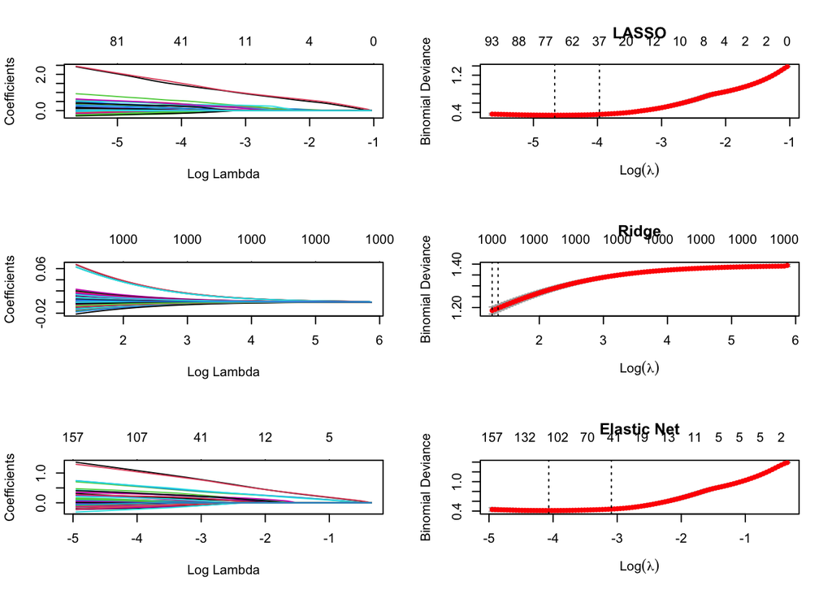

```r
# Plot solution paths:
par(mfrow=c(3,2))
# For plotting options, type '?plot.glmnet' in R console
plot(fit.lasso, xvar="lambda")
plot(fit.lasso.cv, main="LASSO")

plot(fit.ridge, xvar="lambda")
plot(fit.ridge.cv, main="Ridge")

plot(fit.elnet, xvar="lambda")
plot(fit.elnet.cv, main="Elastic Net")
```

## Indep X

**Generate data**

```r
set.seed(24)
n <- 500    # Number of observations
p <- 1000     # Number of predictors included in model
x <- replicate(n=p,rnorm(n,0,1)) # X matrix
logitp <-  4 * apply(x[, 1:2], 1, sum) +
  2 * apply(x[, 3:5], 1, sum) +
  apply(x[, 6:15], 1, sum)  # the first 15 variables are informative of class

prb <- expit(logitp)     # probabilty y=1
y <- rbinom(length(prb),1,prb)  # y is class 1 with probability prb and class 0 otherwise
table(prb>0.5,y)        # table of probability vs class (1/0)
```

```
##        y
##           0   1
##   FALSE 251  18
##   TRUE   22 209
```

```r
# Split data into train and test sets
train_rows <- sample(1:n, .66*n)
x.train <- x[train_rows, ]
x.test <- x[-train_rows, ]

y.train <- y[train_rows]
y.test <- y[-train_rows]
```

**fit models**

```r
set.seed(34)
list.of.fits <- list()
for (i in 0:10){
  fit.name <- paste0("alpha", i/10)

  list.of.fits[[fit.name]] <-
    cv.glmnet(x.train, y.train, type.measure = "deviance", alpha = i/10,
              family = "binomial")
}

results <- data.frame()
for (i in 0:10){
  fit.name <- paste0("alpha", i/10)

  predicted <-
    predict(list.of.fits[[fit.name]] ,
           s = list.of.fits[[fit.name]]$lambda.1se, newx = x.test)

  confumat <- table(y.test,predicted>0)
  error.rate <- (confumat[1,2] + confumat[2,1])/sum(confumat)

  temp  <- data.frame(alpha = i/10, error.rate =  error.rate, fit.name = fit.name)
  results <- rbind(results,temp)
}
results
```

```
##    alpha error.rate fit.name
## 1    0.0  0.4411765   alpha0
## 2    0.1  0.2235294 alpha0.1
## 3    0.2  0.1529412 alpha0.2
## 4    0.3  0.1411765 alpha0.3
## 5    0.4  0.1294118 alpha0.4
## 6    0.5  0.1411765 alpha0.5
## 7    0.6  0.1352941 alpha0.6
## 8    0.7  0.1235294 alpha0.7
## 9    0.8  0.1294118 alpha0.8
## 10   0.9  0.1235294 alpha0.9
## 11   1.0  0.1235294   alpha1
```